# Visualising and Plotting Data

ASI: Introduction to R

Author

Affiliation

Dr Stevie Pederson

Black Ochre Data Labs  
The Kids Research Institute Australia

Published

September 2, 2025

# Visualisation in R

## Start a New R Script

- Call the new script: `BasicVisualisation.R`
- Load our favourite package at the top of the script

```r
library(tidyverse)
```

- Load the `my_penguins` dataset

```r
my_penguins <- read_csv("data/my_penguins.csv")
```

## Introducing The Penguins

```r
my_penguins
```

```
# A tibble: 333 × 8
   species island    bill_length_mm bill_depth_mm flipper_length_mm body_mass_g
   <chr>   <chr>              <dbl>         <dbl>             <dbl>       <dbl>
 1 Adelie  Torgersen           39.1          18.7               181        3750
 2 Adelie  Torgersen           39.5          17.4               186        3800
 3 Adelie  Torgersen           40.3          18                 195        3250
 4 Adelie  Torgersen           36.7          19.3               193        3450
 5 Adelie  Torgersen           39.3          20.6               190        3650
 6 Adelie  Torgersen           38.9          17.8               181        3625
 7 Adelie  Torgersen           39.2          19.6               195        4675
 8 Adelie  Torgersen           41.1          17.6               182        3200
 9 Adelie  Torgersen           38.6          21.2               191        3800
10 Adelie  Torgersen           34.6          21.1               198        4400
# ℹ 323 more rows
# ℹ 2 more variables: sex <chr>, year <dbl>
```

- Contains multiple measurements for penguins recorded around Palmer Station, Antarctica
- Slightly modified version from https://allisonhorst.github.io/palmerpenguins/

## Base Plotting in R

- `R` comes with some very powerful plotting capabilities
  - Provided in the base package `graphics`
  - Always loaded with every session
- Examples are often extremely helpful
- People used happily for decades
  - The release of `ggplot2` changed everything
- Let’s quickly explore base plotting before moving to the good stuff

## Base Plotting In R

- Simple plots are usually easy
  - Complex figures can get really messy
- Using the `cars` dataset
  - `speed` (mph)
  - `dist` (ft) each car takes to stop

```r
plot(cars)
```

## Base Plotting In R

- The first two columns were automatically placed on the x & y axis
- We could set values for x & y manually
- Automatically decided to plot using points

```r
plot(x = cars$speed, y = cars$dist)
```

## Base Plotting In R

- Using the `my_penguins` dataset to compare flipper length and body mass

```r
plot(x = my_penguins$body_mass_g, y = my_penguins$flipper_length_mm)
```

## Base Plotting In R

- The function `boxplot()` can also create simple figures easily
- For categorical variables (i.e. factors) we use `R` formula notation
  - `y ~ x` $\implies$ `y` *depends on* `x`, or
  - `y ~ x` $\implies$ `y` *is a function of* `x`

```r
## Make a simple boxplot showing the weights by species
boxplot(body_mass_g ~ species, data = my_penguins)
```

- The dependent variable will always appear on the y-axis
- The predictor will always appear on the x-axis

## Base Plotting In R

- We can also use combinations of predictor variables

```r
## Separate by species and sex
boxplot(body_mass_g ~ sex + species, data = my_penguins)
```

## Base Plotting In R

- Histograms can be produced on an individual column
  - The number of breaks can be set manually
- The default is pretty useful here
  - Generally simple figures without complexity

```r
hist(my_penguins$body_mass_g, breaks = 20, xlab = "Body Mass (g)")
```

# Visualisation With `ggplot2`

## The Grammar of Graphics

- `ggplot2` has become the industry standard for visualisation (Wickham 2016)
- Core & essential part of the `tidyverse`
- Developed by Hadley Wickham as his PhD thesis
- An implementation of *The Grammar of Graphics* (Wilkinson 2005)
  - Breaks visualisation into *layers*
  - Each layer added as a new line of code

## Beginning Our Plot

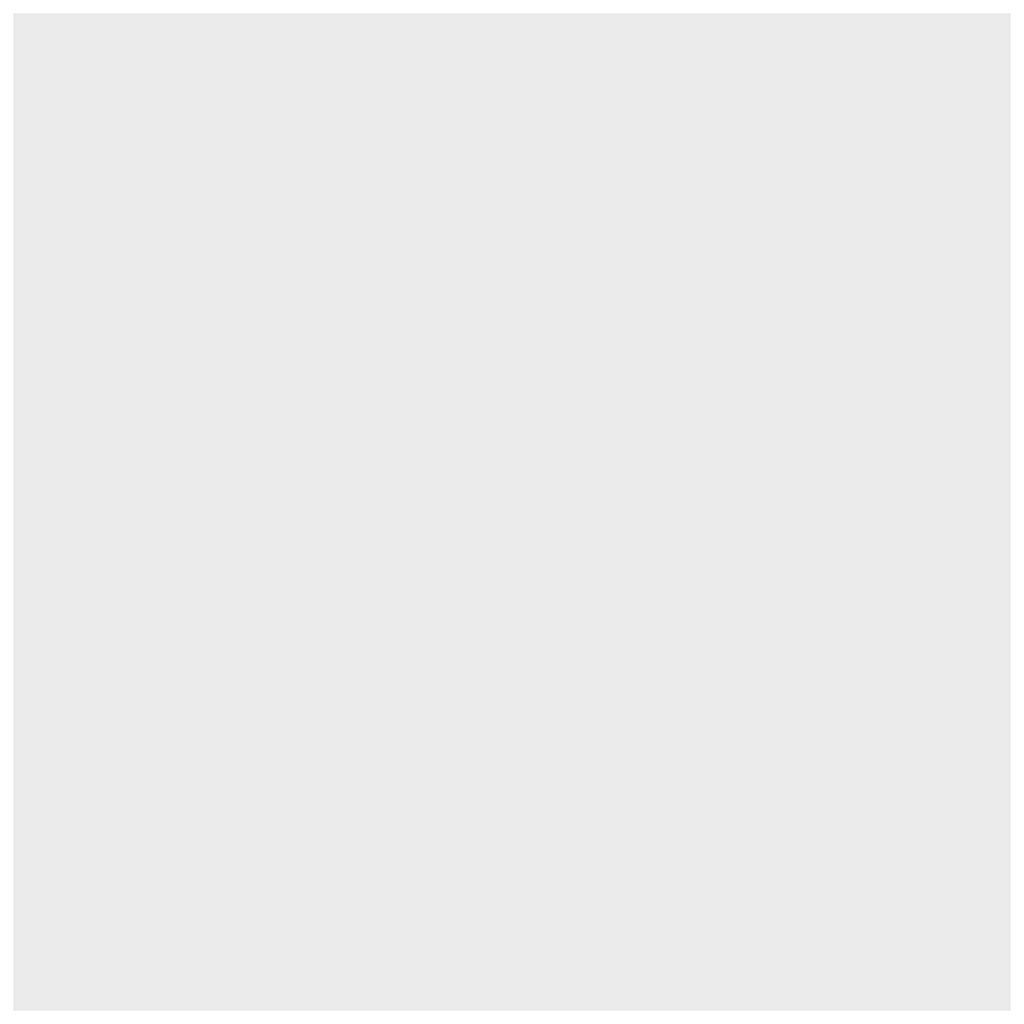

```r
## The initial call to ggplot defines
## the data layer only
ggplot(my_penguins)
```

## Adding Layers

- I’m spreading my code to fit the narrow column in the slide

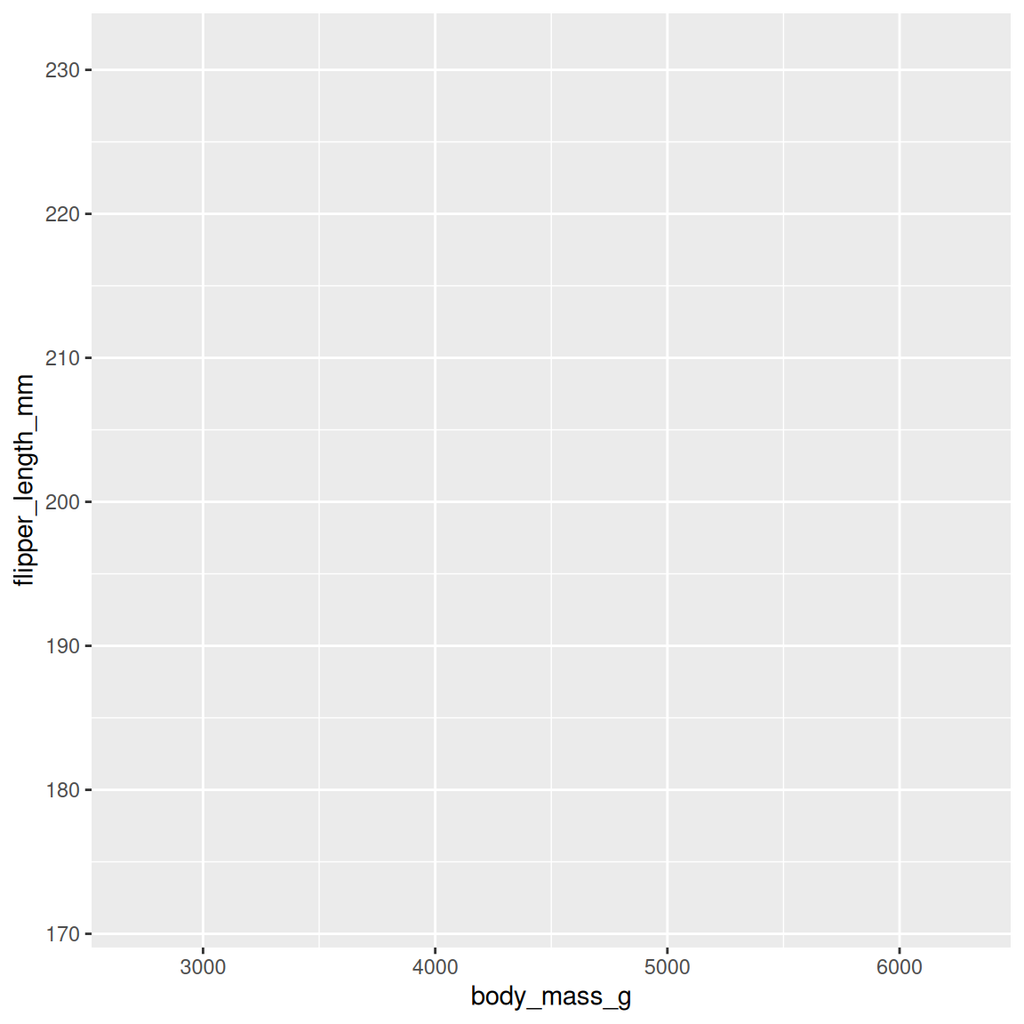

```r
## Adding aesthetic mappings sets the
## data range (via the axes)
ggplot(my_penguins) +
  aes(
    x = body_mass_g,
    y = flipper_length_mm
  )
```

## Adding Layers

- Notice how the call to `ggplot()` was followed by `+`
- This tells `R`: “But wait, there’s more to come!”
- Is how we add the layers described in *The Grammar of Graphics*

## Adding Points

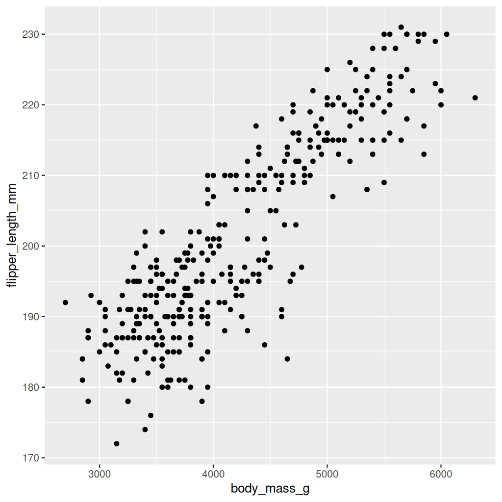

```r
## Adding `geom_point()` now tells
## ggplot what geometry to use
ggplot(my_penguins) +
  aes(
    x = body_mass_g,
    y = flipper_length_mm
  ) +
  geom_point()
```

## Tidying The Code

- To write more clearly

```r
ggplot(my_penguins) + # 1: Define the data layer
  aes(x = body_mass_g, y = flipper_length_mm) + # 2: Aesthetic mappings
  geom_point() # 3: Geometry
```

## Adding Layers

- I’ll hide my figures from here to the code looks nicer
- Now we can easily add additional layers
  - e.g. a smooth curve as a statistics layer

```r
ggplot(my_penguins) + # 1: Define the data layer
  aes(x = body_mass_g, y = flipper_length_mm) + # 2: Aesthetic mappings
  geom_point() + # 3: Geometry
  stat_smooth() # 5: Statistics
```

## Adding Layers

- Change to a regression line without an error region:
  - `method = "lm", se = FALSE`

```r
ggplot(my_penguins) + # 1: Define the data layer
  aes(x = body_mass_g, y = flipper_length_mm) + # 2: Aesthetic mappings
  geom_point() + # 3: Geometry
  stat_smooth(method = "lm", se = FALSE) # 5: Statistics
```

## Additional Aesthetics

- We might like to colour points by species
- Adding this to the main `aes()` will send this mapping to all layers
  - Will produce a regression line for each species

```r
ggplot(my_penguins) + # 1: Define the data layer
  aes(x = body_mass_g, y = flipper_length_mm, colour = species) + # 2: Mappings
  geom_point() +  # 3: Geometry
  stat_smooth(method = "lm", se = FALSE) # 5: Statistics
```

## Additional Aesthetics

- We can also include the `sex` of penguins on this figure
- Can easily add as an aesthetic mapping

```r
ggplot(my_penguins) + # 1: Define the data layer
  aes(x = body_mass_g, y = flipper_length_mm, colour = species, shape = sex) +
  geom_point() +  # 3: Geometry
  stat_smooth(method = "lm", se = FALSE) # 5: Statistics
```

- This doesn’t work well for the regression lines
- Lines don’t have a shape aesthetic $\implies$ ignored by `stat_smooth()`

## Additional Aesthetics

- Aesthetic mappings set in the first call are passed to all layers
- Aesthetics can also be set as *layer-specific*

```r
ggplot(my_penguins) + # 1: Define the data layer
  aes(x = body_mass_g, y = flipper_length_mm, colour = species) + # 2: Mappings
  geom_point(aes(shape = sex)) +  # 3: Geometry with layer-specific aes
  stat_smooth(method = "lm", se = FALSE) # 5: Statistics
```

## Facets

- Separate panels are known as *facets* in `ggplot2`
  - Plot male & female penguins in separate panels

```r
ggplot(my_penguins) + # 1: Define the data layer
  aes(x = body_mass_g, y = flipper_length_mm, colour = species) + # 2: Mappings
  geom_point(aes(shape = sex)) +  # 3: Geometry with layer-specific aes
  facet_wrap(~sex) + # 4: Facets
  stat_smooth(method = "lm", se = FALSE) # 5: Statistics
```

## Facets

- We can “free” each axis within each panel
  - Not always informative

```r
ggplot(my_penguins) + # 1: Define the data layer
  aes(x = body_mass_g, y = flipper_length_mm, colour = species) + # 2: Mappings
  geom_point(aes(shape = sex)) +  # 3: Geometry with layer-specific aes
  facet_wrap(~sex, scales = "free") + # 4: Facets
  stat_smooth(method = "lm", se = FALSE) # 5: Statistics
```

## Co-ordinates

- An additional layer is the co-ordinate system
  - Defaults are *always* chosen (unlike geometry)
  - Can modify if we choose
- Quite obvious for points
  - Can transform axes to log<sub>10</sub> etc
- Applies to colours and shapes as well
- Set using `scale_*()` functions

## Co-ordinates

- Manually set the point shapes
- The options can be seen using `?pch`

```r
ggplot(my_penguins) + # 1: Define the data layer
  aes(x = body_mass_g, y = flipper_length_mm, colour = species) + # 2: Mappings
  geom_point(aes(shape = sex)) +  # 3: Geometry with layer-specific aes
  facet_wrap(~sex, scales = "free") + # 4: Facets
  stat_smooth(method = "lm", se = FALSE) + # 5: Statistics
  scale_shape_manual(values = c(1, 19)) # 6: Co-ordinates (i.e. scales)
```

## Co-ordinates

- Colour scales are also set like this
  - `scale_colour_brewer()` is an excellent starting point

```r
ggplot(my_penguins) + # 1: Define the data layer
  aes(x = body_mass_g, y = flipper_length_mm, colour = species) + # 2: Mappings
  geom_point(aes(shape = sex)) +  # 3: Geometry with layer-specific aes
  facet_wrap(~sex, scales = "free") + # 4: Facets
  stat_smooth(method = "lm", se = FALSE) + # 5: Statistics
  scale_shape_manual(values = c(1, 19)) + # 6: Co-ordinates (i.e. scales)
  scale_colour_brewer(palette = "Set1")
```

- Check `brewer` palettes using `RColorBrewer::display.brewer.all()`

## Co-ordinates

- Multiple options for discrete colour palettes
  - `scale_colour_manual(values = c("red", "blue", "green"))`
  - `scale_colour_viridis_d()`
- Colourblind palettes are provided in `ggthemes`
  - `scale_colour_colorblind()`

## Co-ordinates

```r
library(ggthemes)
ggplot(my_penguins) + # 1: Define the data layer
  aes(x = body_mass_g, y = flipper_length_mm, colour = species) + # 2: Mappings
  geom_point(aes(shape = sex)) +  # 3: Geometry with layer-specific aes
  facet_wrap(~sex, scales = "free") + # 4: Facets
  stat_smooth(method = "lm", se = FALSE) + # 5: Statistics
  scale_shape_manual(values = c(1, 19)) + # 6: Co-ordinates (i.e. scales)
  scale_colour_colorblind() # Stoopid American spelling
```

- Scales often require an understanding of discrete vs continuous, e.g.
  - `scale_x_continuous()` for continuous data
  - `scale_x_discrete()` for categorical data
  - `scale_colour_gradient()` for continuous data (e.g. heatmaps)

## Themes

- The final grammar of graphics layer $\implies$ themes
- Controls overall appearance:
  - font-sizes, background style, title/legend placement etc
- Will explore in detail later if we have time
- We do need to get rid of the horrible grey background though

## Themes

- `theme_bw()` applies a generally usable set of defaults

```r
library(ggthemes)
ggplot(my_penguins) + # 1: Define the data layer
  aes(x = body_mass_g, y = flipper_length_mm, colour = species) + # 2: Mappings
  geom_point(aes(shape = sex)) +  # 3: Geometry with layer-specific aes
  facet_wrap(~sex, scales = "free") + # 4: Facets
  stat_smooth(method = "lm", se = FALSE) + # 5: Statistics
  scale_shape_manual(values = c(1, 19)) + # 6: Co-ordinates (i.e. scales)
  scale_colour_colorblind() + # Stoopid American spelling
  theme_bw() # 7: The overall theme
```

- I often call `theme_set(theme_bw())` at the start of a session
  - Sets as the theme for all subsequent plots

# Additional Geometries

## Additional Geometries

- The choice of appropriate geometry is usually data-driven
  - Same principle as `aes()` / `geom_point()`
  - May have different mappings
- Lines: `geom_line()`, `geom_abline()`, `geom_hline()`, `geom_vline()`
- Distributions: `geom_boxplot()`, `geom_violin()`
- Histograms: `geom_histogram()`, `geom_density()`
- Bar Plots: `geom_bar()`, `geom_col()` + `geom_errorbar()`
- Heatmaps: `geom_tile()`, `geom_raster()`, `geom_rect()`

## Making Boxplots

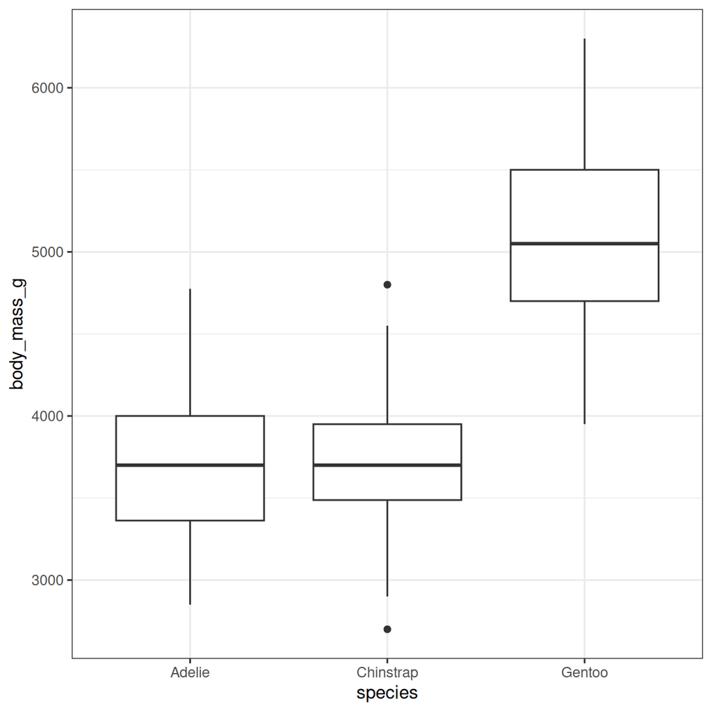

```r
ggplot(
  my_penguins,
  aes(species, body_mass_g)
) +
  geom_boxplot() +
  theme_bw()
```

## Making Boxplots

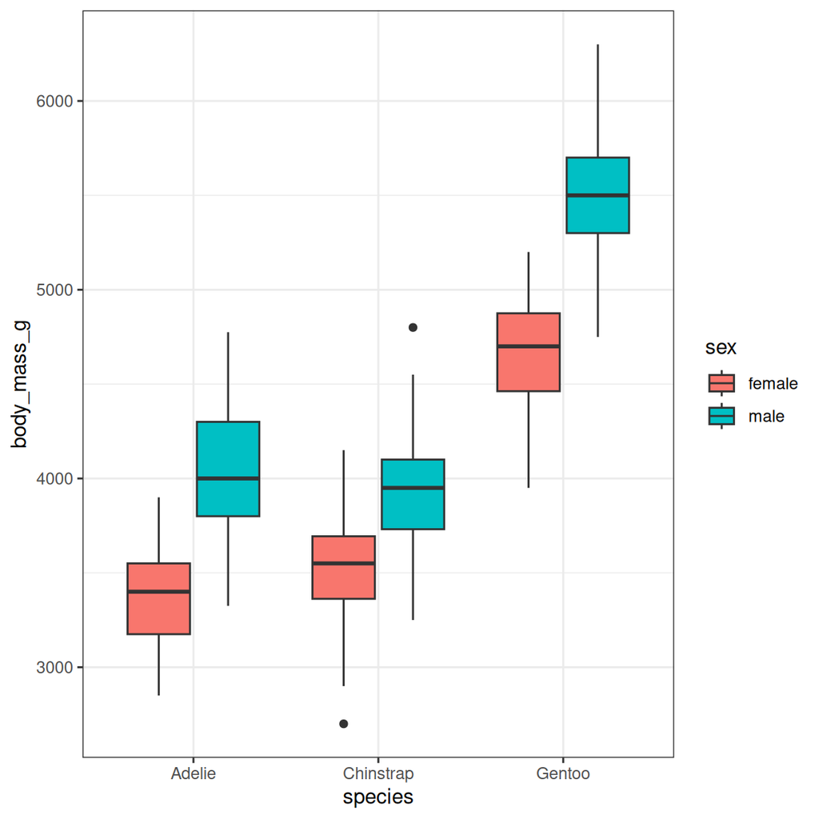

```r
## Map sex to the fill aesthetic
ggplot(my_penguins) +
  aes(
    species, body_mass_g, fill = sex
  ) +
  geom_boxplot() +
  theme_bw()
```

## Histograms

- The default histogram usually looks terrible $\implies$ easy to fix

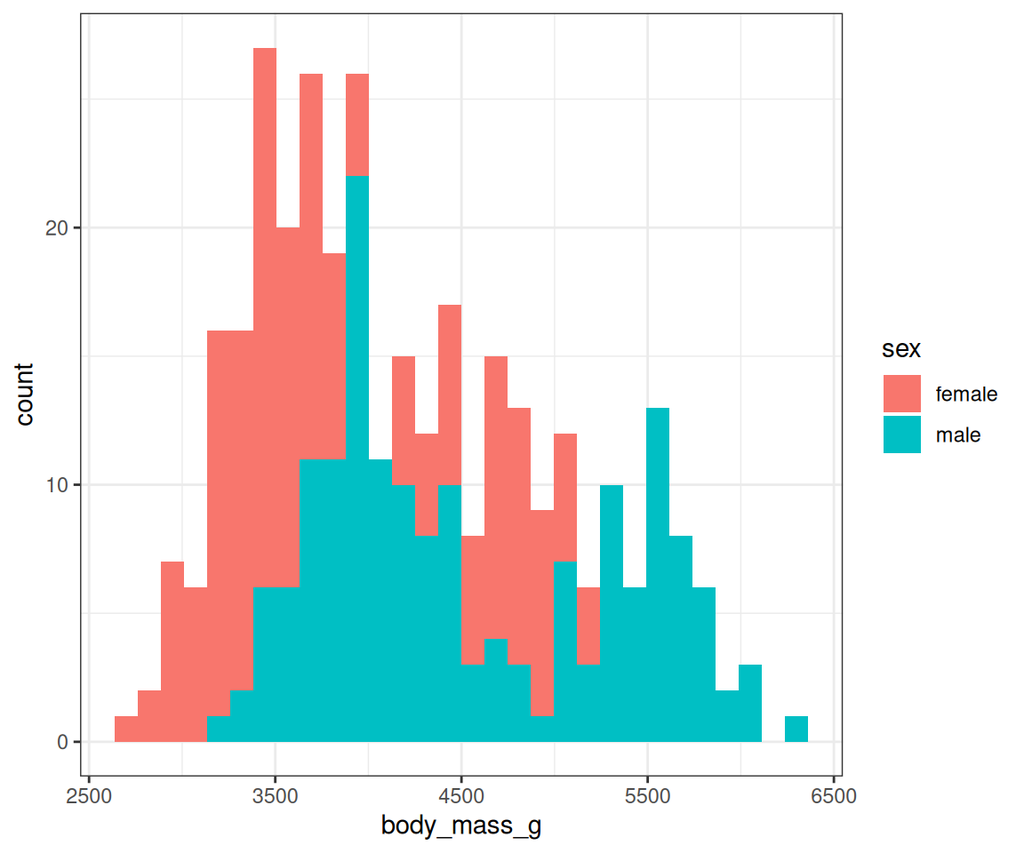

```r
## Map sex to the fill aesthetic
ggplot(my_penguins) +
  aes(x = body_mass_g, fill = sex) +
  geom_histogram() +
  theme_bw()
```

## Histograms

- The default histogram usually looks terrible $\implies$ easy to fix
  - Changing `binwidth` and setting `colour` (outline)

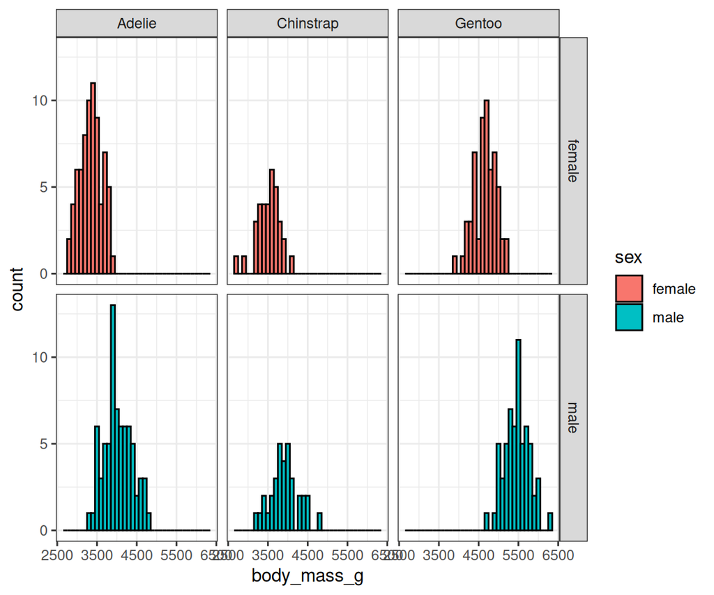

```r
ggplot(my_penguins) +
  aes(x = body_mass_g, fill = sex) +
  geom_histogram(
    colour = "black", binwidth = 100
  ) +
  facet_grid(sex~species) +
  theme_bw()
```

## Closing Comments

- The top-level `aes()` can also be set in the first call to `ggplot()`
  - Is personal preference $\implies$ showed layers clearly today

```r
## My code usually looks more like this
ggplot(
  my_penguins,
  aes(x = body_mass_g, fill = sex)
) +
  geom_histogram(colour = "black", binwidth = 100) +
  facet_grid(sex~species) +
  theme_bw()
```

## Closing Comments

- Will explore additional geometries through the course
- Also discuss more detailed `ggplot2` customisation
- Non `ggplot2` options can also be effective:
  - `corrplot()` from the package `corrplot`
  - `pheatmap()` from the package `pheatmap`
  - Venn Diagrams from `VennDiagram`
  - UpSet plots from `UpSetR` (is actually `ggplot`)

## Challenge

1. Load the `pigs` dataset and create a boxplot
   - Show `dose` across the x-axis
   - Fill by supplement type
2. Experiment with `geom_violin()` as an alternative

## References

Wickham, Hadley. 2016. *Ggplot2: Elegant Graphics for Data Analysis*. Springer-Verlag New York. https://ggplot2.tidyverse.org.

Wilkinson, Leland. 2005. *The Grammar of Graphics*. Springer New York, NY. https://doi.org/https://doi.org/10.1007/0-387-28695-0.